# Data698_Modelling

Dilip Ganesan

4/3/2019

```r
#Load data set
dataset <- read.csv("https://raw.githubusercontent.com/dilipganesan/DATA698/master/Cleaned_Data/Cleaned_DATA698_Dataset.csv")
#dataset
# Cleaning the column X.
#dataset <- dataset %>%
dataset <-dplyr::select(dataset, - X)

#dataset = dataset %>%
#            dplyr::select(-c("Primary_Diag","Secondary_Diag_1","Secondary_Diag_2", #"Payment","diag_1","diag_2","diag_3", "DRG"))

dataset <- dplyr::select(dataset, - c(Primary_Diag,Secondary_Diag_1,Secondary_Diag_2, Payment,diag_1,diag_2,diag_3, DRG ) )


summary(dataset)
```

```
##       race           gender            age        admission_type_id
##  Min.   :1.000   Min.   :0.0000   Min.   : 5.00   Min.   :1.000
##  1st Qu.:4.000   1st Qu.:0.0000   1st Qu.:55.00   1st Qu.:1.000
##  Median :4.000   Median :0.0000   Median :65.00   Median :1.000
##  Mean   :3.525   Mean   :0.4627   Mean   :65.88   Mean   :1.783
##  3rd Qu.:4.000   3rd Qu.:1.0000   3rd Qu.:75.00   3rd Qu.:3.000
##  Max.   :5.000   Max.   :1.0000   Max.   :95.00   Max.   :5.000
##  discharge_disposition_id admission_source_id time_in_hospital
##  Min.   : 1.000           Min.   : 1.000      Min.   : 1.000
##  1st Qu.: 1.000           1st Qu.: 1.000      1st Qu.: 2.000
##  Median : 1.000           Median : 7.000      Median : 4.000
##  Mean   : 2.601           Mean   : 5.887      Mean   : 4.391
##  3rd Qu.: 2.000           3rd Qu.: 7.000      3rd Qu.: 6.000
##  Max.   :25.000           Max.   :20.000      Max.   :14.000
##  num_lab_procedures num_procedures num_medications number_outpatient
##  Min.   :  1.00     Min.   :0.00   Min.   : 1.00   Min.   : 0.0000
##  1st Qu.: 31.00     1st Qu.:0.00   1st Qu.:10.00   1st Qu.: 0.0000
##  Median : 44.00     Median :1.00   Median :15.00   Median : 0.0000
##  Mean   : 42.97     Mean   :1.33   Mean   :15.98   Mean   : 0.3687
##  3rd Qu.: 57.00     3rd Qu.:2.00   3rd Qu.:20.00   3rd Qu.: 0.0000
##  Max.   :132.00     Max.   :6.00   Max.   :81.00   Max.   :42.0000
##  number_emergency  number_inpatient  number_diagnoses max_glu_serum
##  Min.   : 0.0000   Min.   : 0.0000   Min.   : 1.00    Min.   :-99.0
##  1st Qu.: 0.0000   1st Qu.: 0.0000   1st Qu.: 6.00    1st Qu.:-99.0
##  Median : 0.0000   Median : 0.0000   Median : 8.00    Median :-99.0
##  Mean   : 0.1985   Mean   : 0.6334   Mean   : 7.41    Mean   :-93.8
##  3rd Qu.: 0.0000   3rd Qu.: 1.0000   3rd Qu.: 9.00    3rd Qu.:-99.0
##  Max.   :76.0000   Max.   :21.0000   Max.   :16.00    Max.   :  1.0
##    A1Cresult        metformin      repaglinide       nateglinide
##  Min.   :-99.00   Min.   :0.000   Min.   :0.00000   Min.   :0.000000
##  1st Qu.:-99.00   1st Qu.:0.000   1st Qu.:0.00000   1st Qu.:0.000000
##  Median :-99.00   Median :0.000   Median :0.00000   Median :0.000000
##  Mean   :-82.18   Mean   :0.199   Mean   :0.01527   Mean   :0.006944
##  3rd Qu.:-99.00   3rd Qu.:0.000   3rd Qu.:0.00000   3rd Qu.:0.000000
##  Max.   :  1.00   Max.   :1.000   Max.   :1.00000   Max.   :1.000000
##  chlorpropamide       glimepiride      acetohexamide     glipizide
##  Min.   :0.0000000   Min.   :0.00000   Min.   :0e+00   Min.   :0.0000
##  1st Qu.:0.0000000   1st Qu.:0.00000   1st Qu.:0e+00   1st Qu.:0.0000
##  Median :0.0000000   Median :0.00000   Median :0e+00   Median :0.0000
##  Mean   :0.0008504   Mean   :0.05148   Mean   :1e-05   Mean   :0.1261
```

[output cut: 36 more lines]

```
##  Max.   :1e+00          Max.   :1.0000   Max.   :1.0000   Max.   :1.0000
##  primarydiagclass secondarydiagclass_1 tertiarydiagclass_1
##  Min.   :0.000    Min.   :0.000        Min.   :0.0
##  1st Qu.:1.000    1st Qu.:1.000        1st Qu.:1.0
##  Median :2.000    Median :2.000        Median :2.0
##  Mean   :3.299    Mean   :3.436        Mean   :3.3
##  3rd Qu.:5.000    3rd Qu.:7.000        3rd Qu.:6.0
##  Max.   :8.000    Max.   :8.000        Max.   :8.0
##  DRGClassification
##  Min.   : 0.000
##  1st Qu.: 4.000
##  Median : 5.000
##  Mean   : 6.865
##  3rd Qu.: 9.000
##  Max.   :25.000
```

```r
# Renaming certain column namse.

# Creation of addition variables from Raghu Code.
dataset['service_utilization'] <- dataset['number_outpatient'] +
   dataset['number_emergency'] + dataset['number_inpatient']
############ Removing some of medication data from data set because of class imbalance.
summary(dataset)
```

```
##       race           gender            age        admission_type_id
##  Min.   :1.000   Min.   :0.0000   Min.   : 5.00   Min.   :1.000
##  1st Qu.:4.000   1st Qu.:0.0000   1st Qu.:55.00   1st Qu.:1.000
##  Median :4.000   Median :0.0000   Median :65.00   Median :1.000
##  Mean   :3.525   Mean   :0.4627   Mean   :65.88   Mean   :1.783
##  3rd Qu.:4.000   3rd Qu.:1.0000   3rd Qu.:75.00   3rd Qu.:3.000
##  Max.   :5.000   Max.   :1.0000   Max.   :95.00   Max.   :5.000
##  discharge_disposition_id admission_source_id time_in_hospital
##  Min.   : 1.000           Min.   : 1.000      Min.   : 1.000
##  1st Qu.: 1.000           1st Qu.: 1.000      1st Qu.: 2.000
##  Median : 1.000           Median : 7.000      Median : 4.000
##  Mean   : 2.601           Mean   : 5.887      Mean   : 4.391
##  3rd Qu.: 2.000           3rd Qu.: 7.000      3rd Qu.: 6.000
##  Max.   :25.000           Max.   :20.000      Max.   :14.000
##  num_lab_procedures num_procedures num_medications number_outpatient
##  Min.   :  1.00     Min.   :0.00   Min.   : 1.00   Min.   : 0.0000
##  1st Qu.: 31.00     1st Qu.:0.00   1st Qu.:10.00   1st Qu.: 0.0000
##  Median : 44.00     Median :1.00   Median :15.00   Median : 0.0000
##  Mean   : 42.97     Mean   :1.33   Mean   :15.98   Mean   : 0.3687
##  3rd Qu.: 57.00     3rd Qu.:2.00   3rd Qu.:20.00   3rd Qu.: 0.0000
##  Max.   :132.00     Max.   :6.00   Max.   :81.00   Max.   :42.0000
##  number_emergency  number_inpatient  number_diagnoses max_glu_serum
##  Min.   : 0.0000   Min.   : 0.0000   Min.   : 1.00    Min.   :-99.0
##  1st Qu.: 0.0000   1st Qu.: 0.0000   1st Qu.: 6.00    1st Qu.:-99.0
##  Median : 0.0000   Median : 0.0000   Median : 8.00    Median :-99.0
##  Mean   : 0.1985   Mean   : 0.6334   Mean   : 7.41    Mean   :-93.8
##  3rd Qu.: 0.0000   3rd Qu.: 1.0000   3rd Qu.: 9.00    3rd Qu.:-99.0
##  Max.   :76.0000   Max.   :21.0000   Max.   :16.00    Max.   :  1.0
##    A1Cresult        metformin      repaglinide       nateglinide
##  Min.   :-99.00   Min.   :0.000   Min.   :0.00000   Min.   :0.000000
##  1st Qu.:-99.00   1st Qu.:0.000   1st Qu.:0.00000   1st Qu.:0.000000
##  Median :-99.00   Median :0.000   Median :0.00000   Median :0.000000
##  Mean   :-82.18   Mean   :0.199   Mean   :0.01527   Mean   :0.006944
##  3rd Qu.:-99.00   3rd Qu.:0.000   3rd Qu.:0.00000   3rd Qu.:0.000000
##  Max.   :  1.00   Max.   :1.000   Max.   :1.00000   Max.   :1.000000
##  chlorpropamide       glimepiride      acetohexamide     glipizide
##  Min.   :0.0000000   Min.   :0.00000   Min.   :0e+00   Min.   :0.0000
##  1st Qu.:0.0000000   1st Qu.:0.00000   1st Qu.:0e+00   1st Qu.:0.0000
##  Median :0.0000000   Median :0.00000   Median :0e+00   Median :0.0000
##  Mean   :0.0008504   Mean   :0.05148   Mean   :1e-05   Mean   :0.1261
```

[output cut: 36 more lines]

```
##  Max.   :1e+00          Max.   :1.0000   Max.   :1.0000   Max.   :1.0000
##  primarydiagclass secondarydiagclass_1 tertiarydiagclass_1
##  Min.   :0.000    Min.   :0.000        Min.   :0.0
##  1st Qu.:1.000    1st Qu.:1.000        1st Qu.:1.0
##  Median :2.000    Median :2.000        Median :2.0
##  Mean   :3.299    Mean   :3.436        Mean   :3.3
##  3rd Qu.:5.000    3rd Qu.:7.000        3rd Qu.:6.0
##  Max.   :8.000    Max.   :8.000        Max.   :8.0
##  DRGClassification service_utilization
##  Min.   : 0.000    Min.   : 0.000
##  1st Qu.: 4.000    1st Qu.: 0.000
##  Median : 5.000    Median : 0.000
##  Mean   : 6.865    Mean   : 1.201
##  3rd Qu.: 9.000    3rd Qu.: 2.000
##  Max.   :25.000    Max.   :80.000
```

```r
newdataset <-
            dplyr::select(dataset, c("race","gender","age", "admission_type_id","discharge_disposition_id","admission_source_id","time_in_hospital", "num_lab_procedures","num_procedures","num_medications","number_outpatient","number_emergency","number_inpatient","number_diagnoses","max_glu_serum","A1Cresult","metformin","glimepiride","glipizide","glyburide","pioglitazone","rosiglitazone","insulin","change","service_utilization","diabetesMed","readmitted","primarydiagclass","secondarydiagclass_1","tertiarydiagclass_1","DRGClassification"))


########### Modelling
table(newdataset$readmitted )
```

```
##
##     0     1
## 88603 11347
```

```r
### Checking of class bias. The number of events happening is less than events not happening. So for prepartion of dataset to be careful.
# Create Training Data
input_ones <- newdataset[which(newdataset$readmitted == 1), ]  # all 1's
input_zeros <- newdataset[which(newdataset$readmitted == 0), ]  # all 0's
set.seed(100)  # for repeatability of samples
input_ones_training_rows <- sample(1:nrow(input_ones), 0.7*nrow(input_ones))  # 1's for training
input_zeros_training_rows <- sample(1:nrow(input_zeros), 0.7*nrow(input_ones))  # 0's for training. Pick as many 0's as 1's
training_ones <- input_ones[input_ones_training_rows, ]
training_zeros <- input_zeros[input_zeros_training_rows, ]
trainingData <- rbind(training_ones, training_zeros)  # row bind the 1's and 0's

# Create Test Data
test_ones <- input_ones[-input_ones_training_rows, ]
test_zeros <- input_zeros[-input_zeros_training_rows, ]
testData <- rbind(test_ones, test_zeros)  # row bind the 1's and 0's
###########################GLM####################
logitMod <- glm(readmitted ~ ., data=trainingData, family=binomial(link="logit"))

#predicted <- plogis(predict(logitMod, testData))  # predicted scores
# or
predicted <- predict(logitMod, testData, type="response")  # predicted scores
####################
predicted <- ifelse(predicted > 0.5, 1, 0)
predicted_2 <- ifelse(predicted == 1, "TRUE", "FALSE")
mean(predicted==testData$readmitted) # Accuracy: 64.6%
```

```
## [1] 0.6787524
```

```r
################Optimal Cutoff#################
library(InformationValue)
optCutOff <- optimalCutoff(testData$readmitted, predicted)[1]
optCutOff
```

```
## [1] 0.01
```

```r
##############vif############
require(fmsb)
require(car)
```

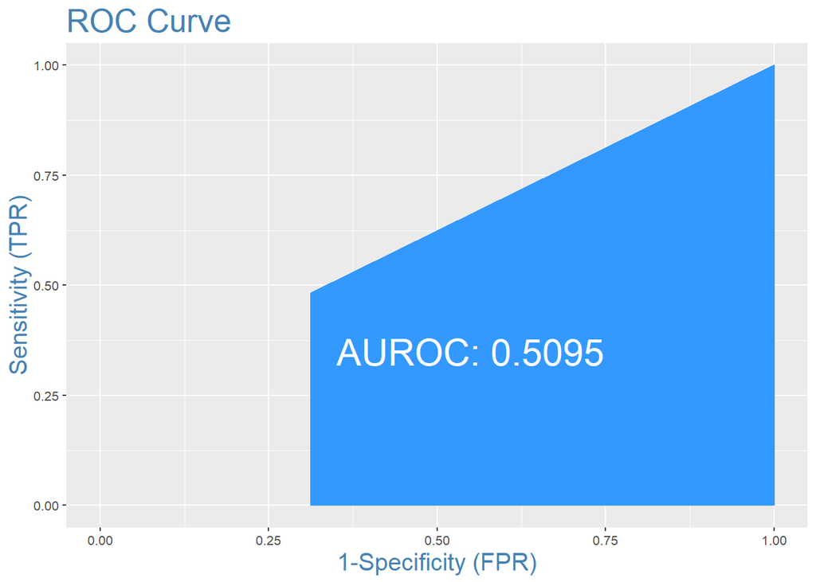

```r
#vif(logitMod)
##########
plotROC(testData$readmitted, predicted)
```

```r
###################ConfusionMatrix#######
confusionMatrix(testData$readmitted, predicted, threshold = optCutOff)
```

```
##       0    1
## 0 55415 1760
## 1 25246 1645
```

```r
require(randomForest)
#######################Random Forrest#################
table(trainingData$readmitted )
```

```
##
##    0    1
## 7942 7942
```

```r
table(testData$readmitted )
```

```
##
##     0     1
## 80661  3405
```

```r
trainingData$readmitted <- ifelse(trainingData$readmitted == 1, "TRUE", "FALSE")
testData$readmitted <- ifelse(testData$readmitted == 1, "TRUE", "FALSE")
trainingData$readmitted <- as.factor(trainingData$readmitted)
testData$readmitted <- as.factor(testData$readmitted)
table(trainingData$readmitted )
```

```
##
## FALSE  TRUE
##  7942  7942
```

```r
model.rf1 <-randomForest(readmitted ~. , data=trainingData[,-1], ntree=10, na.action=na.exclude, importance=T,proximity=T)

print(model.rf1)
```

```
##
## Call:
##  randomForest(formula = readmitted ~ ., data = trainingData[,      -1], ntree = 10, importance = T, proximity = T, na.action = na.exclude)
##                Type of random forest: classification
##                      Number of trees: 10
## No. of variables tried at each split: 5
##
##         OOB estimate of  error rate: 44.38%
## Confusion matrix:
##       FALSE TRUE class.error
## FALSE  4624 3232   0.4114053
## TRUE   3747 4123   0.4761118
```

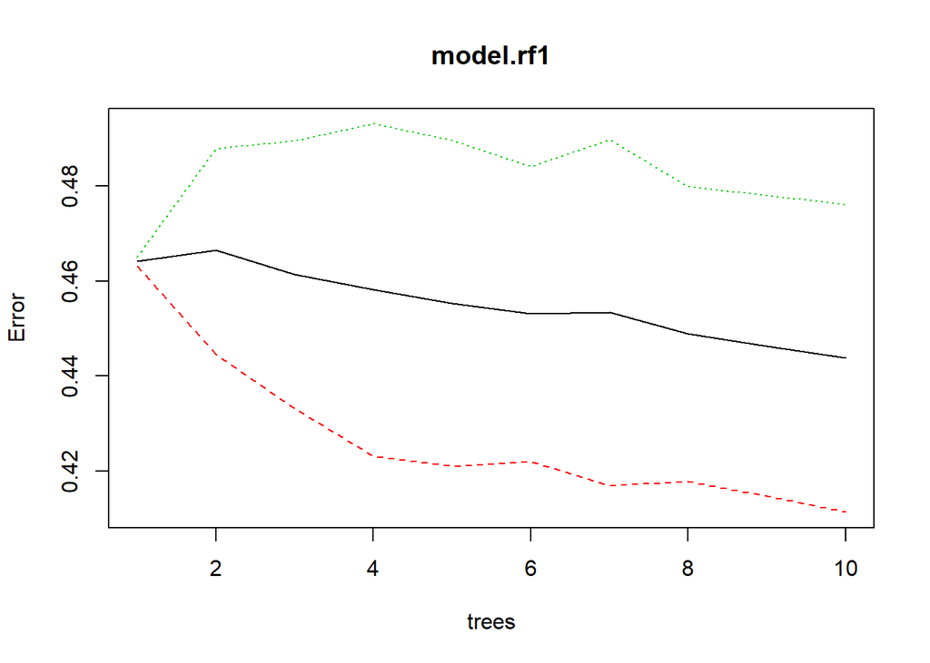

```r
#model.rf2 <-randomForest(readmitted ~. , data=trainingData, ntree=20, na.action=na.exclude, importance=T,proximity=T)
#print(model.rf2)
#model.rf3 <-randomForest(readmitted~., data=trainingData, ntree=30, na.action=na.exclude, importance=T,proximity=T)
#print(model.rf3)
#model.rf4 <-randomForest(readmitted~., data=trainingData, ntree=40, na.action=na.exclude, importance=T,proximity=T)
#print(model.rf4)
#model.rf5 <-randomForest(readmitted~., data=trainingData, ntree=50, na.action=na.exclude, importance=T,proximity=T)
#print(model.rf5)
#mtry <- tuneRF(trainingData[,-1], trainingData$readmitted, ntreeTry=40,stepFactor=1.5, improve=0.01, trace=TRUE, plot=TRUE)

#model.rf <- randomForest(readmitted~., data=trainingData, ntree=40, mtry = 8, na.action=na.exclude, importance=T,proximity=T)
#pred.rf <- predict(model.rf, testData)
#mean(pred.rf==testData$readmitted) # Accuracy: 60.86%

plot(model.rf1)
```

```r
############################ NN Network############
require(neuralnet)
require(nnet)
model.nn <- nnet(readmitted ~., data=trainingData[,-1], size=5, maxit=1000)
pred.nn <- predict(model.nn, testData,type= "raw")
pred.nn <- ifelse(pred.nn > 0.5, "TRUE", "FALSE")
mean(pred.nn==testData$readmitted) # Accuracy: 65.61%
```

```
## [1] 0.4755787
```

```r
#plotnet(model.nn)
```

## Correlations

there is positive correlation between service_utiliation and number_outpatient, inpatient and emergency.

Also diabetesMed has correlation between insulin and change

max_glu_serum has correlation between admission_source_id and admission_type_id

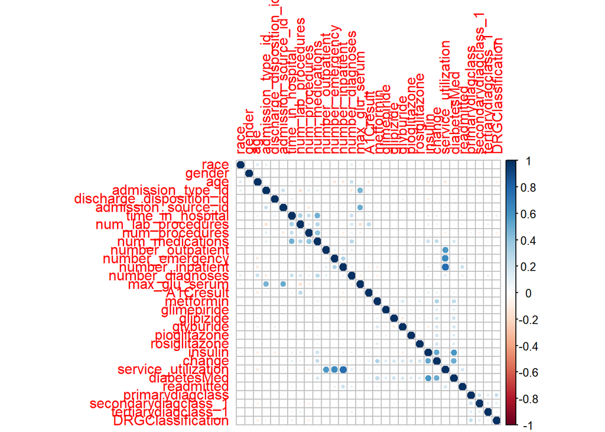

```r
library(corrplot)
#M<-as.matrix(trainingData)
#str(trainingData)
trainingData$readmitted<-as.numeric(trainingData$readmitted)
M<-cor(trainingData)

#c_train <- corrplot(trainingData, method="pearson", use="complete.obs")

corrplot(M, method="circle")
```

## Decision Tree:

The machine learning behind this method is to figure out which variable and which threshold to use at every split. One advantage of tree-based methods is that they have no assumptions about the structure of the data and are able to pick up non-linear effects if given sufficient tree depth. We can fit decision trees using the following code.

```r
############################ Decision Tree ############
library(rpart.plot)
require(caret)
trctrl <- trainControl(method = "repeatedcv", number = 10, repeats = 3)
#set.seed(3333)
dtree_fit <- train(readmitted ~., data = trainingData, method = "rpart",
                   parms = list(split = "information"),
                   trControl=trctrl,
                   tuneLength = 10)
dtree_fit
```

```
## CART
##
## 15884 samples
##    30 predictor
##
## No pre-processing
## Resampling: Cross-Validated (10 fold, repeated 3 times)
## Summary of sample sizes: 14296, 14296, 14295, 14295, 14294, 14296, ...
## Resampling results across tuning parameters:
##
##   cp            RMSE       Rsquared    MAE
##   0.0008954804  0.4828055  0.06844196  0.4639929
##   0.0010184748  0.4827970  0.06842078  0.4644151
##   0.0011587199  0.4826647  0.06886367  0.4647497
##   0.0013848134  0.4828860  0.06799089  0.4653450
##   0.0016895390  0.4829858  0.06757992  0.4658118
##   0.0027292612  0.4839396  0.06391421  0.4676075
##   0.0027634416  0.4840555  0.06346665  0.4678309
##   0.0092109267  0.4856040  0.05749917  0.4710539
##   0.0134713508  0.4886856  0.04547913  0.4769571
##   0.0404370301  0.4960541  0.03211978  0.4908907
##
## RMSE was used to select the optimal model using the smallest value.
## The final value used for the model was cp = 0.00115872.
```

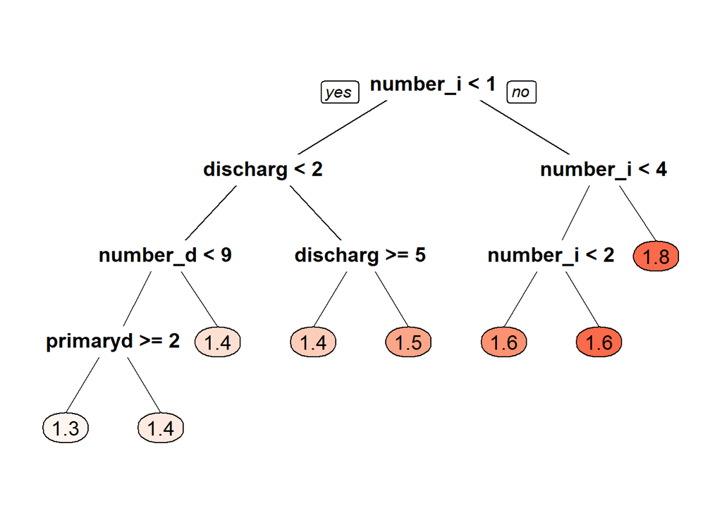

```r
prp(dtree_fit$finalModel, box.palette = "Reds", tweak = 1.2)
```

```r
#model.nn <- nnet(readmitted ~., data=trainingData[,-1], size=5, maxit=1000)
pred.nn <- predict(dtree_fit, testData,type= "raw")
#pred.nn <- ifelse(pred.nn > 0.5, "TRUE", "FALSE")
table_mat <- table(testData$readmitted,pred.nn)
table_mat
```

```
##        pred.nn
##         1.28415841584158 1.36858974358974 1.40705563093623
##   FALSE            13821             8150            13774
##   TRUE               259              208              387
##        pred.nn
##         1.40740740740741 1.52265324252295 1.55183213279048
##   FALSE             3313            16271            15189
##   TRUE                96              809              758
##        pred.nn
##         1.64314426083073 1.79740518962076
##   FALSE             7889             2254
##   TRUE               570              318
```

```r
mean(pred.nn==testData$readmitted) # Accuracy: 60.8%
```

```
## [1] 0
```

```r
confusionMatrix(pred.nn, testData$readmitted )  #check accuracy
```

```
## [1] 1.28415841584158 1.36858974358974 1.40705563093623 1.40740740740741
## [5] 1.52265324252295 1.55183213279048 1.64314426083073 1.79740518962076
## <0 rows> (or 0-length row.names)
```

```r
########################
# Classification Tree with rpart
require(rpart)

# grow tree
fit <- rpart(readmitted ~.,
   method="class", data=trainingData)

printcp(fit) # display the results
```

```
##
## Classification tree:
## rpart(formula = readmitted ~ ., data = trainingData, method = "class")
##
## Variables actually used in tree construction:
## [1] number_inpatient
##
## Root node error: 7942/15884 = 0.5
##
## n= 15884
##
##        CP nsplit rel error  xerror      xstd
## 1 0.19743      0   1.00000 1.01851 0.0079331
## 2 0.01000      1   0.80257 0.80257 0.0077783
```

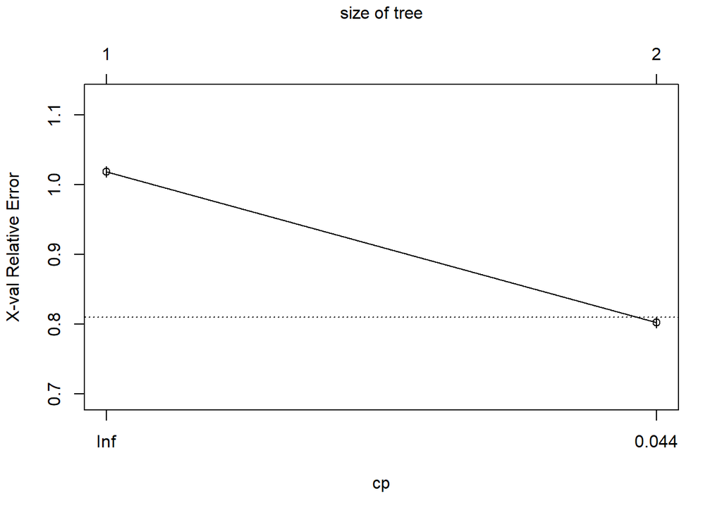

```r
plotcp(fit) # visualize cross-validation results
```

```r
summary(fit) # detailed summary of splits
```

```
## Call:
## rpart(formula = readmitted ~ ., data = trainingData, method = "class")
##   n= 15884
##
##          CP nsplit rel error    xerror        xstd
## 1 0.1974314      0 1.0000000 1.0185092 0.007933150
## 2 0.0100000      1 0.8025686 0.8025686 0.007778332
##
## Variable importance
##    number_inpatient service_utilization    number_emergency
##                  52                  38                   6
##   number_outpatient   DRGClassification
##                   3                   1
##
## Node number 1: 15884 observations,    complexity param=0.1974314
##   predicted class=1  expected loss=0.5  P(node) =1
##     class counts:  7942  7942
##    probabilities: 0.500 0.500
##   left son=2 (9450 obs) right son=3 (6434 obs)
##   Primary splits:
##       number_inpatient         < 0.5  to the left,  improve=321.15090, (0 missing)
##       service_utilization      < 1.5  to the left,  improve=244.86700, (0 missing)
##       discharge_disposition_id < 1.5  to the left,  improve=110.47510, (0 missing)
##       number_emergency         < 1.5  to the left,  improve= 67.35234, (0 missing)
##       number_diagnoses         < 5.5  to the left,  improve= 53.38487, (0 missing)
##   Surrogate splits:
##       service_utilization < 0.5  to the left,  agree=0.889, adj=0.726, (0 split)
##       number_emergency    < 0.5  to the left,  agree=0.643, adj=0.118, (0 split)
##       number_outpatient   < 0.5  to the left,  agree=0.617, adj=0.054, (0 split)
##       DRGClassification   < 19.5 to the left,  agree=0.604, adj=0.022, (0 split)
##       primarydiagclass    < 0.5  to the right, agree=0.597, adj=0.006, (0 split)
##
## Node number 2: 9450 observations
##   predicted class=1  expected loss=0.417037  P(node) =0.5949383
##     class counts:  5509  3941
##    probabilities: 0.583 0.417
##
## Node number 3: 6434 observations
##   predicted class=2  expected loss=0.3781473  P(node) =0.4050617
##     class counts:  2433  4001
##    probabilities: 0.378 0.622
```

```r
########################
```

## Decision Tree with no DRG:

```r
############################ Decision Tree ############

trainingdata_ndrg=trainingData[, -31]
trctrl <- trainControl(method = "repeatedcv", number = 10, repeats = 3)
#set.seed(3333)
dtree_fit_ndrg <- train(readmitted ~., data = trainingdata_ndrg, method = "rpart",
                   parms = list(split = "information"),
                   trControl=trctrl,
                   tuneLength = 10)
dtree_fit_ndrg
```

```
## CART
##
## 15884 samples
##    29 predictor
##
## No pre-processing
## Resampling: Cross-Validated (10 fold, repeated 3 times)
## Summary of sample sizes: 14296, 14296, 14295, 14295, 14295, 14295, ...
## Resampling results across tuning parameters:
##
##   cp            RMSE       Rsquared    MAE
##   0.0008954804  0.4824328  0.06981261  0.4636885
##   0.0010184748  0.4825479  0.06937833  0.4642313
##   0.0011587199  0.4824888  0.06957407  0.4644585
##   0.0013848134  0.4825938  0.06914136  0.4650922
##   0.0016895390  0.4828878  0.06802591  0.4657764
##   0.0027292612  0.4839591  0.06391338  0.4676804
##   0.0027634416  0.4839823  0.06382058  0.4677331
##   0.0092109267  0.4856928  0.05715059  0.4711340
##   0.0134713508  0.4883631  0.04672834  0.4764093
##   0.0404370301  0.4959522  0.03294496  0.4908340
##
## RMSE was used to select the optimal model using the smallest value.
## The final value used for the model was cp = 0.0008954804.
```

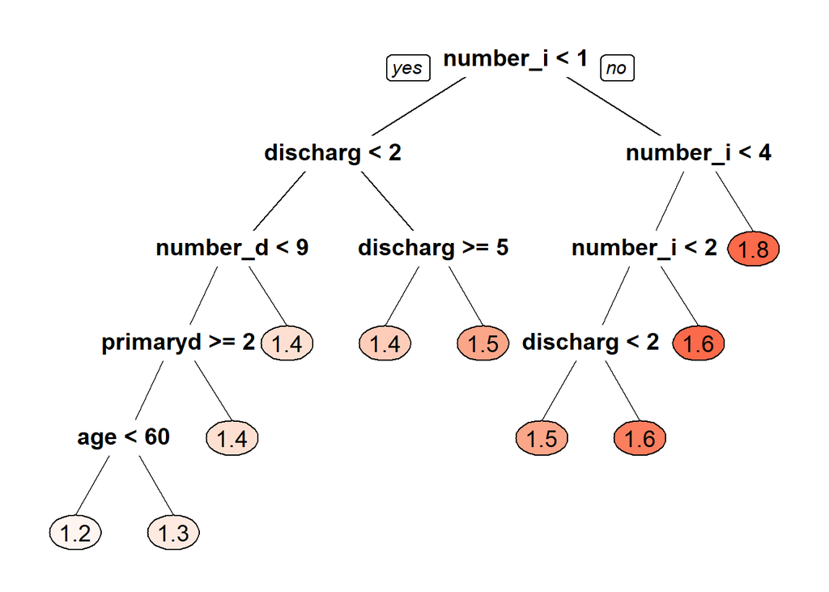

```r
prp(dtree_fit_ndrg$finalModel, box.palette = "Reds", tweak = 1.2)
```

```r
pred.nn <- predict(dtree_fit_ndrg, testData,type= "raw")
table_mat <- table(testData$readmitted,pred.nn)
table_mat
```

```
##        pred.nn
##         1.23833671399594 1.32785299806576 1.36858974358974
##   FALSE             7090             6731             8150
##   TRUE               117              142              208
##        pred.nn
##         1.40705563093623 1.40740740740741 1.51470588235294
##   FALSE            13774             3313             8591
##   TRUE               387               96              385
##        pred.nn
##         1.52265324252295 1.59064702114029 1.64314426083073
##   FALSE            16271             6598             7889
##   TRUE               809              373              570
##        pred.nn
##         1.79740518962076
##   FALSE             2254
##   TRUE               318
```

```r
mean(pred.nn==testData$readmitted) # Accuracy: 60.7%
```

```
## [1] 0
```

```r
confusionMatrix(pred.nn, testData$readmitted )  #check accuracy
```

```
##  [1] 1.23833671399594 1.32785299806576 1.36858974358974 1.40705563093623
##  [5] 1.40740740740741 1.51470588235294 1.52265324252295 1.59064702114029
##  [9] 1.64314426083073 1.79740518962076
## <0 rows> (or 0-length row.names)
```